# tidyverse_recipe: dplyr::case_when

Jimmy Ng

April 18, 2019

## (1) Create an Example

Let’s load the tidyverse package and then load a sample data set from my github account. The original dataset comes from [kaggle](https://www.kaggle.com/vjchoudhary7/customer-segmentation-tutorial-in-python#Mall_Customers.csv). We will look at packages under the tidyverse, functions within “dplyr”, and eventually zoom in into a specific dplyr function “case_when” with a sample use case.

### Set-up

```r
# load package(s)
library(tidyverse)
library(janitor)
library(kableExtra)

# load data
df <- read.csv("https://raw.githubusercontent.com/myvioletrose/school_of_professional_studies/master/607.%20Data%20Acquisition%20and%20Management/%23%20misc/Mall_Customers.csv") %>%
        janitor::clean_names(.)  # using janitor::clean_names() to clean up column names

head(df) %>% kable() %>% kable_styling()
```

| customer_id | gender | age | annual_income_k | spending_score_1_100 |
| --- | --- | --- | --- | --- |
| 1 | Male | 19 | 15 | 39 |
| 2 | Male | 21 | 15 | 81 |
| 3 | Female | 20 | 16 | 6 |
| 4 | Female | 23 | 16 | 77 |
| 5 | Female | 31 | 17 | 40 |
| 6 | Female | 22 | 17 | 76 |

### tidyverse packages

```r
# how many packages live under the tidyverse?
tidyverse_packages()
```

```
##  [1] "broom"      "cli"        "crayon"     "dbplyr"     "dplyr"
##  [6] "forcats"    "ggplot2"    "haven"      "hms"        "httr"
## [11] "jsonlite"   "lubridate"  "magrittr"   "modelr"     "pillar"
## [16] "purrr"      "readr"      "readxl"     "reprex"     "rlang"
## [21] "rstudioapi" "rvest"      "stringr"    "tibble"     "tidyr"
## [26] "xml2"       "tidyverse"
```

### dplyr

```r
# how many functions within "dplyr"?
ls(pos = "package:dplyr")
```

```
##   [1] "%>%"                   "across"                "add_count"
##   [4] "add_count_"            "add_row"               "add_rownames"
##   [7] "add_tally"             "add_tally_"            "all_equal"
##  [10] "all_of"                "all_vars"              "anti_join"
##  [13] "any_of"                "any_vars"              "arrange"
##  [16] "arrange_"              "arrange_all"           "arrange_at"
##  [19] "arrange_if"            "as.tbl"                "as_data_frame"
##  [22] "as_label"              "as_tibble"             "auto_copy"
##  [25] "band_instruments"      "band_instruments2"     "band_members"
##  [28] "bench_tbls"            "between"               "bind_cols"
##  [31] "bind_rows"             "c_across"              "case_when"
##  [34] "changes"               "check_dbplyr"          "coalesce"
##  [37] "collapse"              "collect"               "combine"
##  [40] "common_by"             "compare_tbls"          "compare_tbls2"
##  [43] "compute"               "contains"              "copy_to"
```

[output cut: 82 more lines]

### dplyr::case_when

Here’s an official description: *This function allows you to vectorise multiple if_else() statements. It is an R equivalent of the SQL CASE WHEN statement. If no cases match, NA is returned.*

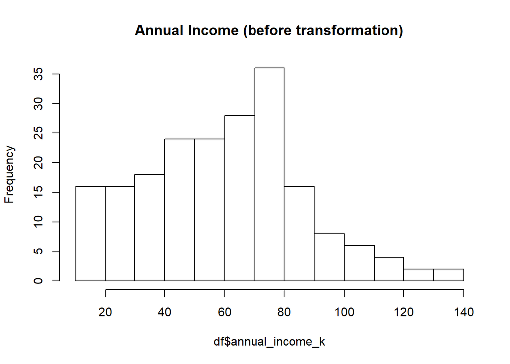

```r
# let's create a new variable using case_when by transforming a numeric variable into buckets
# let's look at the distribution - before transformation
hist(df$annual_income_k, main = "Annual Income (before transformation)")
```

```r
# let's create 10 buckets to represent this numeric variable
buckets <- cut(df$annual_income_k, breaks = 10) %>% levels
buckets
```

```
##  [1] "(14.9,27.2]" "(27.2,39.4]" "(39.4,51.6]" "(51.6,63.8]" "(63.8,76]"
##  [6] "(76,88.2]"   "(88.2,100]"  "(100,113]"   "(113,125]"   "(125,137]"
```

```r
# create a new categorical variable
df$income_bucket <- cut(df$annual_income_k, breaks = 10)
df <- df %>%
        dplyr::mutate(income_bucket = dplyr::case_when(income_bucket == buckets[1] ~ "income level 0",
                                                       income_bucket == buckets[2] ~ "income level 1",
                                                       income_bucket == buckets[3] ~ "income level 2",
                                                       income_bucket == buckets[4] ~ "income level 3",
                                                       income_bucket == buckets[5] ~ "income level 4",
                                                       income_bucket == buckets[6] ~ "income level 5",
                                                       income_bucket == buckets[7] ~ "income level 6",
                                                       income_bucket == buckets[8] ~ "income level 7",
                                                       income_bucket == buckets[9] ~ "income level 8",
                                                       income_bucket == buckets[10] ~ "income level 9",
                                                       TRUE ~ as.character(income_bucket)))

head(df) %>% kable() %>% kable_styling()
```

| customer_id | gender | age | annual_income_k | spending_score_1_100 | income_bucket |
| --- | --- | --- | --- | --- | --- |
| 1 | Male | 19 | 15 | 39 | income level 0 |
| 2 | Male | 21 | 15 | 81 | income level 0 |
| 3 | Female | 20 | 16 | 6 | income level 0 |
| 4 | Female | 23 | 16 | 77 | income level 0 |
| 5 | Female | 31 | 17 | 40 | income level 0 |
| 6 | Female | 22 | 17 | 76 | income level 0 |

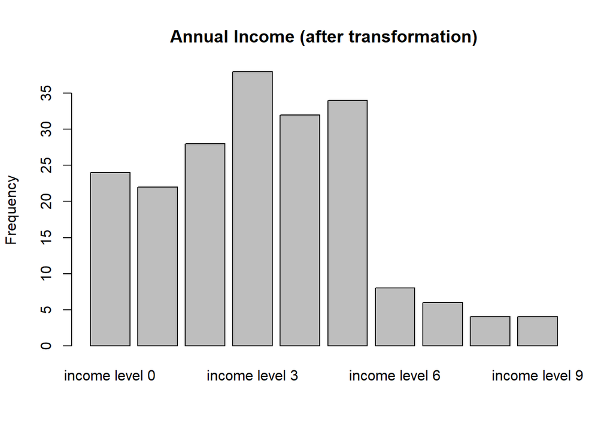

```r
# let's look at the distribution - after transformation
table(df$income_bucket) %>% barplot(., ylab = "Frequency", main = "Annual Income (after transformation)")
```

***

## (2) Extend an Existing Example

I want to extend an existing example from Omar Pineda (“omarp120”). Here, we are looking at [Poll data](https://raw.githubusercontent.com/fivethirtyeight/data/master/ahca-polls/ahca_polls.csv). Do we see higher apporving (or favoring) of the health care bill when “Obama” is mentioned in the question (instead of “American Health Care Act”)? Omar is using “str_detect” to extract “obama” from text and create a column to flag those pollsters out. We are going to transform the data and visualize the result.

```r
ratings <- read.csv("https://raw.githubusercontent.com/fivethirtyeight/data/master/ahca-polls/ahca_polls.csv")

ratings$obama <- str_detect(ratings$Text, "Obamacare")

# before gathering
ratings %>% head() %>% kable() %>% kable_styling()
```

| Start | End | Pollster | Favor | Oppose | Url | Text | obama |
| --- | --- | --- | --- | --- | --- | --- | --- |
| 6/9/17 | 6/11/17 | Public Policy Polling | 24 | 55 | http://www.publicpolicypolling.com/pdf/2017/PPP_Release_National_61217.pdf | Do you support or oppose the health care bill passed by the House last month, known as the American Health Care Act? | FALSE |
| 6/4/17 | 6/6/17 | YouGov | 33 | 45 | https://d25d2506sfb94s.cloudfront.net/cumulus_uploads/document/4vf8rhr0jz/econToplines.pdf | Do you approve or disapprove of the American Health Care Act, the Republican legislation to repeal and replace the Affordable Care Act/Obamacare? | TRUE |
| 5/31/17 | 6/6/17 | Qunnipiac | 17 | 62 | https://poll.qu.edu/national/release-detail?ReleaseID=2463 | There is a revised Republican health care plan to replace Obamacare, known as the American Health Care Act. Do you approve or disapprove of this revised Republican health care plan? | TRUE |
| 5/26/17 | 5/30/17 | IPSOS | 30 | 46 | https://www.realclearpolitics.com/docs/Core_Political-Topline-2017-05-31.pdf | Based on everything you know about the new American Health Care Act (AHCA), to what extent do you support or oppose it? | FALSE |
| 5/25/17 | 5/30/17 | Morning Consult | 38 | 47 | https://morningconsult.com/wp-content/uploads/2017/05/170516_crosstabs_Politico_v3_TB-1.pdf | As you may know, the House of Representatives recently passed a bill called the American Health Care Act that would that repeal and replace the 2010 Affordable Care Act, sometimes referred to as Obama… | TRUE |
| 5/17/17 | 5/23/17 | Quinnipiac | 20 | 57 | https://poll.qu.edu/national/release-detail?ReleaseID=2461 | There is a revised Republican health care plan to replace Obamacare, known as the American Health Care Act. Do you approve or disapprove of this revised Republican health care plan? | TRUE |

```r
ratings.gather <- ratings %>%
        dplyr::select(Start, End, Pollster, Favor, Oppose, obama) %>%
        tidyr::gather(., attitude, percent, -c(Start, End, Pollster, obama)) %>%
        arrange(Start, End, Pollster)

# after gathering the Favor and Oppose columns
ratings.gather %>% kable() %>% kable_styling()
```

| Start | End | Pollster | obama | attitude | percent |
| --- | --- | --- | --- | --- | --- |
| 5/11/17 | 5/15/17 | NBC/WSJ | FALSE | Favor | 23 |
| 5/11/17 | 5/15/17 | NBC/WSJ | FALSE | Oppose | 48 |
| 5/12/17 | 5/16/17 | Public Policy Polling | FALSE | Favor | 25 |
| 5/12/17 | 5/16/17 | Public Policy Polling | FALSE | Oppose | 52 |
| 5/13/17 | 5/16/17 | YouGov | FALSE | Favor | 31 |
| 5/13/17 | 5/16/17 | YouGov | FALSE | Oppose | 47 |
| 5/13/17 | 5/20/17 | Monmouth | TRUE | Favor | 32 |
| 5/13/17 | 5/20/17 | Monmouth | TRUE | Oppose | 55 |
| 5/16/17 | 5/22/17 | Kaiser Family Foundation | FALSE | Favor | 31 |
| 5/16/17 | 5/22/17 | Kaiser Family Foundation | FALSE | Oppose | 55 |
| 5/17/17 | 5/23/17 | Quinnipiac | TRUE | Favor | 20 |
| 5/17/17 | 5/23/17 | Quinnipiac | TRUE | Oppose | 57 |
| 5/25/17 | 5/30/17 | Morning Consult | TRUE | Favor | 38 |
| 5/25/17 | 5/30/17 | Morning Consult | TRUE | Oppose | 47 |
| 5/26/17 | 5/30/17 | IPSOS | FALSE | Favor | 30 |
| 5/26/17 | 5/30/17 | IPSOS | FALSE | Oppose | 46 |
| 5/31/17 | 6/6/17 | Qunnipiac | TRUE | Favor | 17 |
| 5/31/17 | 6/6/17 | Qunnipiac | TRUE | Oppose | 62 |
| 5/4/17 | 5/10/17 | Quinnipiac | TRUE | Favor | 21 |
| 5/4/17 | 5/10/17 | Quinnipiac | TRUE | Oppose | 56 |
| 5/4/17 | 5/9/17 | Morning Consult | TRUE | Favor | 38 |
| 5/4/17 | 5/9/17 | Morning Consult | TRUE | Oppose | 44 |
| 5/6/17 | 5/13/17 | YouGov | FALSE | Favor | 31 |
| 5/6/17 | 5/13/17 | YouGov | FALSE | Oppose | 44 |
| 5/6/17 | 5/6/17 | YouGov | FALSE | Favor | 31 |
| 5/6/17 | 5/6/17 | YouGov | FALSE | Oppose | 47 |
| 6/4/17 | 6/6/17 | YouGov | TRUE | Favor | 33 |
| 6/4/17 | 6/6/17 | YouGov | TRUE | Oppose | 45 |
| 6/9/17 | 6/11/17 | Public Policy Polling | FALSE | Favor | 24 |
| 6/9/17 | 6/11/17 | Public Policy Polling | FALSE | Oppose | 55 |

### ggplot - when Obama is NOT mentioned

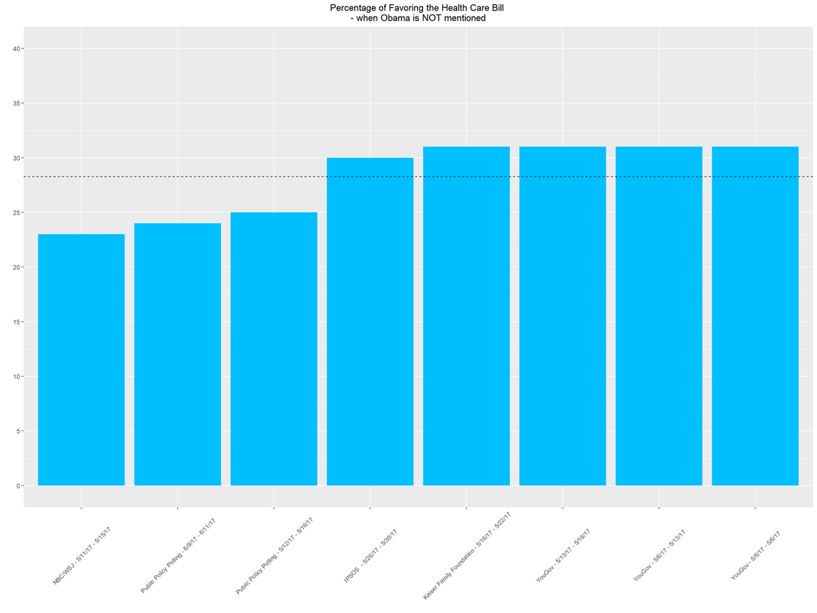

```r
ratings.gather %>%
        dplyr::filter(obama == F & attitude == "Favor") %>%
        ggplot(., aes(x = reorder(paste(Pollster, Start, End, sep = " - "), percent),
                      y = percent, group = attitude)) +
        geom_bar(stat = "identity", position = "stack", fill = "deepskyblue") +
        geom_hline(yintercept = mean(
                ratings.gather$percent[ratings.gather$obama == F &
                                               ratings.gather$attitude == "Favor"]
                ),
                col = "black", linetype = "dashed") +
        scale_y_continuous(limits = c(0, 40), breaks = seq(0, 40, 5)) +
        labs(x = "", y = "") +
        ggtitle("Percentage of Favoring the Health Care Bill \n- when Obama is NOT mentioned") +
        theme(legend.position = "none", plot.title = element_text(hjust = 0.5),
              axis.text.x = element_text(angle = 45, vjust = 0.5, hjust = 0.5))
```

### ggplot - when Obama is mentioned

The result does not seem to make a big difference (when we look at the dashed line representing the average among all pollsters); in fact, mentioning “obama” seems to draw higher approval.

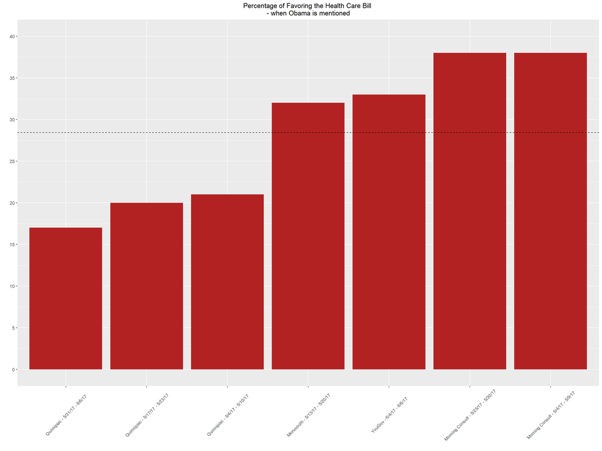

```r
ratings.gather %>%
        dplyr::filter(obama == T & attitude == "Favor") %>%
        ggplot(., aes(x = reorder(paste(Pollster, Start, End, sep = " - "), percent),
                      y = percent, group = attitude)) +
        geom_bar(stat = "identity", position = "stack", fill = "firebrick") +
        geom_hline(yintercept = mean(
                ratings.gather$percent[ratings.gather$obama == T &
                                               ratings.gather$attitude == "Favor"]
                ),
                col = "black", linetype = "dashed") +
        scale_y_continuous(limits = c(0, 40), breaks = seq(0, 40, 5)) +
        labs(x = "", y = "") +
        ggtitle("Percentage of Favoring the Health Care Bill \n- when Obama is mentioned") +
        theme(legend.position = "none", plot.title = element_text(hjust = 0.5),
              axis.text.x = element_text(angle = 45, vjust = 0.5, hjust = 0.5))
```

***